# Stats about COVID-19 victims

## Inserting the database

The code below imports the .csv database with all the data about COVID-19 victims. `dfCovid.drop()` function removes certain columns from the original database.

```python
import numpy as np
import pandas as pd

from sklearn.impute import SimpleImputer as simp

dfCovid = pd.read_csv('C:/Users/hypop/Downloads/owid-covid-data.csv')

dfCovid.drop(['iso_code', 'continent', 'new_cases_smoothed', 'new_cases_smoothed_per_million', 'new_deaths_smoothed', 'new_deaths_smoothed_per_million'], axis=1, inplace=True)
dfCovid[560:580]
```

|  | location | date | total_cases | new_cases | total_deaths | new_deaths | total_cases_per_million | new_cases_per_million | total_deaths_per_million | new_deaths_per_million | ... | diabetes_prevalence | female_smokers | male_smokers | handwashing_facilities | hospital_beds_per_thousand | life_expectancy | human_development_index | excess_mortality_cumulative_absolute | excess_mortality_cumulative | excess_mortality |
| --- | --- | --- | --- | --- | --- | --- | --- | --- | --- | --- | --- | --- | --- | --- | --- | --- | --- | --- | --- | --- | --- |
| 560 | Afghanistan | 2021-09-06 | 153534.0 | 111.0 | 7141.0 | 9.0 | 3854.207 | 2.786 | 179.263 | 0.226 | ... | 9.59 | NaN | NaN | 37.746 | 0.5 | 64.83 | 0.511 | NaN | NaN | NaN |
| 561 | Afghanistan | 2021-09-07 | 153626.0 | 92.0 | 7144.0 | 3.0 | 3856.517 | 2.310 | 179.338 | 0.075 | ... | 9.59 | NaN | NaN | 37.746 | 0.5 | 64.83 | 0.511 | NaN | NaN | NaN |
| 562 | Afghanistan | 2021-09-08 | 153736.0 | 110.0 | 7151.0 | 7.0 | 3859.278 | 2.761 | 179.514 | 0.176 | ... | 9.59 | NaN | NaN | 37.746 | 0.5 | 64.83 | 0.511 | NaN | NaN | NaN |
| 563 | Afghanistan | 2021-09-09 | 153840.0 | 104.0 | 7157.0 | 6.0 | 3861.889 | 2.611 | 179.664 | 0.151 | ... | 9.59 | NaN | NaN | 37.746 | 0.5 | 64.83 | 0.511 | NaN | NaN | NaN |
| 564 | Afghanistan | 2021-09-10 | 153962.0 | 122.0 | 7164.0 | 7.0 | 3864.952 | 3.063 | 179.840 | 0.176 | ... | 9.59 | NaN | NaN | 37.746 | 0.5 | 64.83 | 0.511 | NaN | NaN | NaN |
| 565 | Afghanistan | 2021-09-11 | 153982.0 | 20.0 | 7167.0 | 3.0 | 3865.454 | 0.502 | 179.915 | 0.075 | ... | 9.59 | NaN | NaN | 37.746 | 0.5 | 64.83 | 0.511 | NaN | NaN | NaN |
| 566 | Afghanistan | 2021-09-12 | 153990.0 | 8.0 | 7167.0 | 0.0 | 3865.654 | 0.201 | 179.915 | 0.000 | ... | 9.59 | NaN | NaN | 37.746 | 0.5 | 64.83 | 0.511 | NaN | NaN | NaN |
| 567 | Afghanistan | 2021-09-13 | 154094.0 | 104.0 | 7169.0 | 2.0 | 3868.265 | 2.611 | 179.965 | 0.050 | ... | 9.59 | NaN | NaN | 37.746 | 0.5 | 64.83 | 0.511 | NaN | NaN | NaN |
| 568 | Afghanistan | 2021-09-14 | 154180.0 | 86.0 | 7171.0 | 2.0 | 3870.424 | 2.159 | 180.016 | 0.050 | ... | 9.59 | NaN | NaN | 37.746 | 0.5 | 64.83 | 0.511 | NaN | NaN | NaN |
| 569 | Afghanistan | 2021-09-15 | 154283.0 | 103.0 | 7174.0 | 3.0 | 3873.010 | 2.586 | 180.091 | 0.075 | ... | 9.59 | NaN | NaN | 37.746 | 0.5 | 64.83 | 0.511 | NaN | NaN | NaN |
| 570 | Afghanistan | 2021-09-16 | 154361.0 | 78.0 | 7183.0 | 9.0 | 3874.968 | 1.958 | 180.317 | 0.226 | ... | 9.59 | NaN | NaN | 37.746 | 0.5 | 64.83 | 0.511 | NaN | NaN | NaN |
| 571 | Afghanistan | 2021-09-17 | 154487.0 | 126.0 | 7186.0 | 3.0 | 3878.131 | 3.163 | 180.392 | 0.075 | ... | 9.59 | NaN | NaN | 37.746 | 0.5 | 64.83 | 0.511 | NaN | NaN | NaN |
| 572 | Afghanistan | 2021-09-18 | 154487.0 | 0.0 | 7186.0 | 0.0 | 3878.131 | 0.000 | 180.392 | 0.000 | ... | 9.59 | NaN | NaN | 37.746 | 0.5 | 64.83 | 0.511 | NaN | NaN | NaN |
| 573 | Afghanistan | 2021-09-19 | 154487.0 | 0.0 | 7186.0 | 0.0 | 3878.131 | 0.000 | 180.392 | 0.000 | ... | 9.59 | NaN | NaN | 37.746 | 0.5 | 64.83 | 0.511 | NaN | NaN | NaN |
| 574 | Afghanistan | 2021-09-20 | 154585.0 | 98.0 | 7199.0 | 13.0 | 3880.591 | 2.460 | 180.719 | 0.326 | ... | 9.59 | NaN | NaN | 37.746 | 0.5 | 64.83 | 0.511 | NaN | NaN | NaN |
| 575 | Afghanistan | 2021-09-21 | 154712.0 | 127.0 | 7199.0 | 0.0 | 3883.779 | 3.188 | 180.719 | 0.000 | ... | 9.59 | NaN | NaN | 37.746 | 0.5 | 64.83 | 0.511 | NaN | NaN | NaN |
| 576 | Afghanistan | 2021-09-22 | 154757.0 | 45.0 | 7199.0 | 0.0 | 3884.909 | 1.130 | 180.719 | 0.000 | ... | 9.59 | NaN | NaN | 37.746 | 0.5 | 64.83 | 0.511 | NaN | NaN | NaN |
| 577 | Afghanistan | 2021-09-23 | 154800.0 | 43.0 | 7199.0 | 0.0 | 3885.988 | 1.079 | 180.719 | 0.000 | ... | 9.59 | NaN | NaN | 37.746 | 0.5 | 64.83 | 0.511 | NaN | NaN | NaN |
| 578 | Afghanistan | 2021-09-24 | 154960.0 | 160.0 | 7199.0 | 0.0 | 3890.005 | 4.017 | 180.719 | 0.000 | ... | 9.59 | NaN | NaN | 37.746 | 0.5 | 64.83 | 0.511 | NaN | NaN | NaN |
| 579 | Afghanistan | 2021-09-25 | 154960.0 | 0.0 | 7199.0 | 0.0 | 3890.005 | 0.000 | 180.719 | 0.000 | ... | 9.59 | NaN | NaN | 37.746 | 0.5 | 64.83 | 0.511 | NaN | NaN | NaN |

20 rows × 58 columns

## Database information

```python
dfCovid.describe()
```

|  | total_cases | new_cases | total_deaths | new_deaths | total_cases_per_million | new_cases_per_million | total_deaths_per_million | new_deaths_per_million | reproduction_rate | icu_patients | ... | diabetes_prevalence | female_smokers | male_smokers | handwashing_facilities | hospital_beds_per_thousand | life_expectancy | human_development_index | excess_mortality_cumulative_absolute | excess_mortality_cumulative | excess_mortality |
| --- | --- | --- | --- | --- | --- | --- | --- | --- | --- | --- | --- | --- | --- | --- | --- | --- | --- | --- | --- | --- | --- |
| count | 1.132970e+05 | 113294.00000 | 1.025660e+05 | 102721.000000 | 112700.000000 | 112697.000000 | 101982.000000 | 102137.000000 | 95729.000000 | 13516.000000 | ... | 108888.000000 | 82506.000000 | 81308.000000 | 53066.000000 | 96075.000000 | 113121.000000 | 105745.000000 | 4132.000000 | 4132.000000 | 4207.000000 |
| mean | 1.399103e+06 | 6453.53626 | 3.567316e+04 | 145.747617 | 17272.429156 | 82.660737 | 363.232070 | 1.556048 | 1.007532 | 943.125777 | ... | 8.009696 | 10.597120 | 32.735718 | 50.746674 | 3.024455 | 73.258887 | 0.726605 | 27472.271031 | 7.944584 | 14.965103 |
| std | 9.382581e+06 | 39395.96895 | 2.126574e+05 | 794.631219 | 29636.369371 | 192.871726 | 619.301892 | 4.073426 | 0.347614 | 2905.408021 | ... | 4.270938 | 10.505233 | 13.500747 | 31.753572 | 2.453268 | 7.543199 | 0.150234 | 80443.208509 | 16.013207 | 31.373302 |
| min | 1.000000e+00 | -74347.00000 | 1.000000e+00 | -1918.000000 | 0.001000 | -3125.829000 | 0.001000 | -75.911000 | -0.070000 | 0.000000 | ... | 0.990000 | 0.100000 | 7.700000 | 1.188000 | 0.100000 | 53.280000 | 0.394000 | -31959.400000 | -27.350000 | -95.920000 |
| 25% | 1.916000e+03 | 3.00000 | 6.600000e+01 | 0.000000 | 333.629250 | 0.278000 | 10.052000 | 0.000000 | 0.840000 | 25.000000 | ... | 5.310000 | 1.900000 | 21.600000 | 19.351000 | 1.300000 | 67.920000 | 0.602000 | -287.125000 | -1.680000 | -1.735000 |
| 50% | 1.970600e+04 | 91.00000 | 5.870000e+02 | 2.000000 | 2604.888000 | 10.466000 | 66.403000 | 0.150000 | 1.010000 | 121.000000 | ... | 7.110000 | 6.300000 | 31.400000 | 49.839000 | 2.400000 | 74.620000 | 0.744000 | 1290.900000 | 3.975000 | 5.560000 |
| 75% | 2.061060e+05 | 915.00000 | 5.016750e+03 | 19.000000 | 20562.251250 | 80.390000 | 436.328500 | 1.365000 | 1.180000 | 550.000000 | ... | 10.080000 | 19.300000 | 41.100000 | 82.502000 | 3.861000 | 78.740000 | 0.848000 | 16880.550000 | 12.902500 | 21.265000 |
| max | 2.315160e+08 | 906034.00000 | 4.743196e+06 | 17976.000000 | 215155.192000 | 8620.690000 | 5972.167000 | 215.334000 | 5.880000 | 28891.000000 | ... | 30.530000 | 44.000000 | 78.100000 | 100.000000 | 13.800000 | 86.750000 | 0.957000 | 647166.900000 | 106.830000 | 372.820000 |

8 rows × 55 columns

The code below shows the basic information about the database: number of columns, number of non-null values inside of each column, type of values contained in each column, etc.

```python
dfCovid.info()
```

```
<class 'pandas.core.frame.DataFrame'>
RangeIndex: 119245 entries, 0 to 119244
Data columns (total 58 columns):
 #   Column                                 Non-Null Count   Dtype
---  ------                                 --------------   -----
 0   location                               119245 non-null  object
 1   date                                   119245 non-null  object
 2   total_cases                            113297 non-null  float64
 3   new_cases                              113294 non-null  float64
 4   total_deaths                           102566 non-null  float64
 5   new_deaths                             102721 non-null  float64
 6   total_cases_per_million                112700 non-null  float64
 7   new_cases_per_million                  112697 non-null  float64
 8   total_deaths_per_million               101982 non-null  float64
 9   new_deaths_per_million                 102137 non-null  float64
```

[output cut: 50 more lines]

## Data grouping

The code below groups all rows that have similar `location` value by summing all the values and reseting indices from 0. The data is not correct (Africa does not have 1.7 bln cases of COVID-19) because of the way that the database was structured — for every `total_cases` (and other) value they've written a cumulative value already.

```python
dfCovidByCountryCumulative = dfCovid.groupby('location')[['total_cases', 'total_cases_per_million', 'total_deaths', 'total_deaths_per_million']].sum().reset_index()
dfCovidByCountryCumulative.head(20)
```

|  | location | total_cases | total_cases_per_million | total_deaths | total_deaths_per_million |
| --- | --- | --- | --- | --- | --- |
| 0 | Afghanistan | 3.282706e+07 | 8.240669e+05 | 1368795.0 | 34361.227 |
| 1 | Africa | 1.672536e+09 | 1.217730e+06 | 42705984.0 | 31093.115 |
| 2 | Albania | 3.632432e+07 | 1.264363e+07 | 671028.0 | 233568.874 |
| 3 | Algeria | 4.749703e+07 | 1.064559e+06 | 1359675.0 | 30474.635 |
| 4 | Andorra | 4.104350e+06 | 5.305931e+07 | 47352.0 | 612146.795 |
| 5 | Angola | 9.871637e+06 | 2.909103e+05 | 240875.0 | 7098.424 |
| 6 | Anguilla | 0.000000e+00 | 0.000000e+00 | 0.0 | 0.000 |
| 7 | Antigua and Barbuda | 3.250100e+05 | 3.291974e+06 | 9316.0 | 94360.334 |
| 8 | Argentina | 1.071969e+09 | 2.350510e+07 | 24213072.0 | 530920.625 |
| 9 | Armenia | 7.028443e+07 | 2.367972e+07 | 1327433.0 | 447229.024 |
| 10 | Aruba | 0.000000e+00 | 0.000000e+00 | 0.0 | 0.000 |
| 11 | Asia | 1.399333e+10 | 2.990245e+06 | 212073782.0 | 45318.208 |
| 12 | Australia | 1.463367e+07 | 5.674558e+05 | 383694.0 | 14878.649 |
| 13 | Austria | 1.775784e+08 | 1.963695e+07 | 2956837.0 | 326972.634 |
| 14 | Azerbaijan | 9.669402e+07 | 9.458160e+06 | 1333190.0 | 130406.443 |
| 15 | Bahamas | 3.947032e+06 | 9.944300e+06 | 83173.0 | 209549.177 |
| 16 | Bahrain | 6.570550e+07 | 3.758262e+07 | 283418.0 | 162111.069 |
| 17 | Bangladesh | 3.038424e+08 | 1.827035e+06 | 4756846.0 | 28603.401 |
| 18 | Barbados | 1.029226e+06 | 3.577328e+06 | 12456.0 | 43293.850 |
| 19 | Belarus | 1.188086e+08 | 1.258183e+07 | 897414.0 | 95036.198 |

## Data Plots

### Total cases by country

New `dfCovidByCountry` data frame takes all the rows that have a `date` value of `2021-09-25` and the indicated fields.

`dfCovidForCountryName` data frame takes all the rows that have a `location` value of `United States` (and all the fields from the original data frame). `len(dfCovidForCountryName['date'])` gives the total number of days after the start of the pandemic. The program plots a scatter of days after the start of the pandemic versus the number of total cases (and ~deaths) for the selected country.

```
Number of countries in dfCovid data frame: 233
Number of countries in dfCovidByCountry data frame: 204
Some countries are lost because they do not have any data for the date 2021-09-25
```

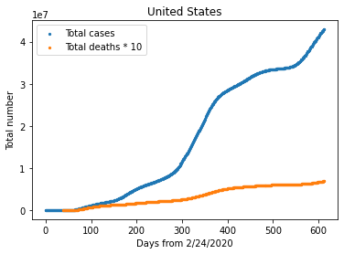

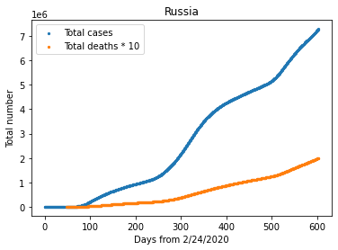

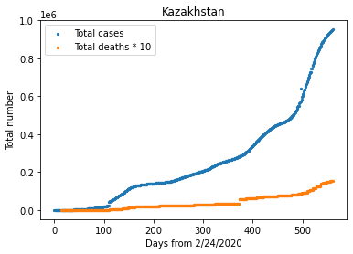

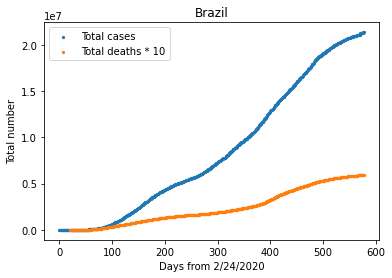

```python
import matplotlib.pyplot as plt

dfCovidByCountry = dfCovid[dfCovid['date'] == '2021-09-25'].reset_index()
dfCovidByCountry2 = dfCovidByCountry[['location', 'date', 'total_cases', 'total_deaths', 'icu_patients', 'people_vaccinated', 'median_age', 'aged_65_older']]
dfCovidByCountry2[150:200] #shows total number of cases, deaths, etc. for 2021-09-25

countries = dfCovid['location'].unique()
print('Number of countries in dfCovid data frame:', len(countries))
#print(countries)

countries2 = dfCovidByCountry['location'].unique()
print('Number of countries in dfCovidByCountry data frame:', len(countries2))
#print(countries2)

print('Some countries are lost because they do not have any data for the date 2021-09-25')



# error = []
# for i in countries:
#     for j in countries2:
#         if i == j:
#             break
#     else:
#         error.append(i)

# print(error)

# dfCovid[(dfCovid['location'] == 'Anguilla')] --- one of the 'lost' countries

countryName = 'United States'
dfCovidForCountryName = dfCovid[dfCovid['location'] == countryName].reset_index()
plt.scatter(np.arange(len(dfCovidForCountryName['date'])), dfCovidForCountryName['total_cases'], s=5, label='Total cases')
plt.scatter(np.arange(len(dfCovidForCountryName['date'])), dfCovidForCountryName['total_deaths'] * 10, s=5, label='Total deaths * 10')
plt.title(countryName)
plt.xlabel('Days from 2/24/2020')
plt.ylabel('Total number')
plt.legend()
plt.show()

countryName = 'Russia'
dfCovidForCountryName = dfCovid[dfCovid['location'] == countryName].reset_index()
plt.scatter(np.arange(len(dfCovidForCountryName['date'])), dfCovidForCountryName['total_cases'], s=5, label='Total cases')
plt.scatter(np.arange(len(dfCovidForCountryName['date'])), dfCovidForCountryName['total_deaths'] * 10, s=5, label='Total deaths * 10')
plt.title(countryName)
plt.xlabel('Days from 2/24/2020')
plt.ylabel('Total number')
plt.legend()
plt.show()

countryName = 'Kazakhstan'
dfCovidForCountryName = dfCovid[dfCovid['location'] == countryName].reset_index()
plt.scatter(np.arange(len(dfCovidForCountryName['date'])), dfCovidForCountryName['total_cases'], s=5, label='Total cases')
plt.scatter(np.arange(len(dfCovidForCountryName['date'])), dfCovidForCountryName['total_deaths'] * 10, s=5, label='Total deaths * 10')
plt.title(countryName)
plt.xlabel('Days from 2/24/2020')
plt.ylabel('Total number')
plt.legend()
plt.show()

countryName = 'Brazil'
dfCovidForCountryName = dfCovid[dfCovid['location'] == countryName].reset_index()
plt.scatter(np.arange(len(dfCovidForCountryName['date'])), dfCovidForCountryName['total_cases'], s=5, label='Total cases')
plt.scatter(np.arange(len(dfCovidForCountryName['date'])), dfCovidForCountryName['total_deaths'] * 10, s=5, label='Total deaths * 10')
plt.title(countryName)
plt.xlabel('Days from 2/24/2020')
plt.ylabel('Total number')
plt.legend()
plt.show()
```

### New cases by country

This code does the same thing as the code above. The difference is that this code plots the new cases for a set of countries, and it is also simpler because of the use of the loop.

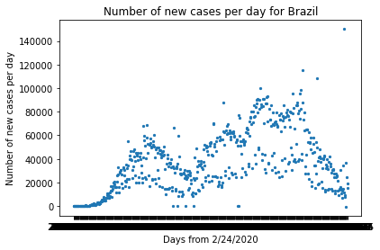

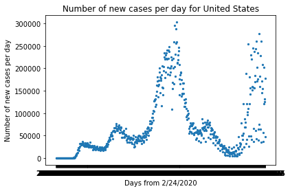

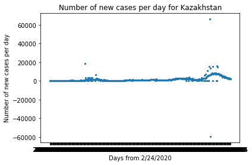

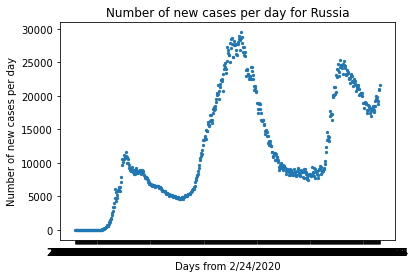

```python
countriesSet = ['Brazil', 'United States', 'Kazakhstan', 'Russia']

for x in countriesSet:
    countryName = x
    dfCovidForCountryName = dfCovid[dfCovid['location'] == countryName].reset_index()
    plt.scatter(dfCovidForCountryName['date'], dfCovidForCountryName['new_cases'], s=5)
    plt.title('Number of new cases per day for ' + x)
    plt.xlabel('Days from 2/24/2020')
    plt.ylabel('Number of new cases per day')
    plt.show()
```

### New cases by country comparison

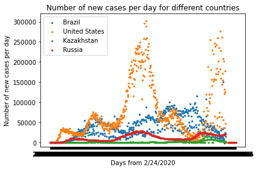

```python
countriesSet = ['Brazil', 'United States', 'Kazakhstan', 'Russia']

for x in countriesSet:
    countryName = x
    dfCovidForCountryName = dfCovid[dfCovid['location'] == countryName].reset_index()
    plt.scatter(dfCovidForCountryName['date'], dfCovidForCountryName['new_cases'], s=5, label=x)

plt.title('Number of new cases per day for different countries')
plt.xlabel('Days from 2/24/2020')
plt.ylabel('Number of new cases per day')
plt.ylim([-10000, 320000])
plt.legend()
plt.show()
```

### New cases per million by country comparison

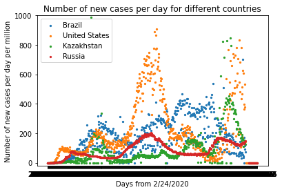

```python
countriesSet = ['Brazil', 'United States', 'Kazakhstan', 'Russia']

for x in countriesSet:
    countryName = x
    dfCovidForCountryName = dfCovid[dfCovid['location'] == countryName].reset_index()
    plt.scatter(dfCovidForCountryName['date'], dfCovidForCountryName['new_cases_per_million'], s=5, label=x)

plt.title('Number of new cases per day for different countries')
plt.xlabel('Days from 2/24/2020')
plt.ylabel('Number of new cases per day per million')
plt.ylim([-20, 1000]) #gets rid of the outliers in Kazakhstan
plt.legend()
plt.show()
```

### GDP per capita versus total cases

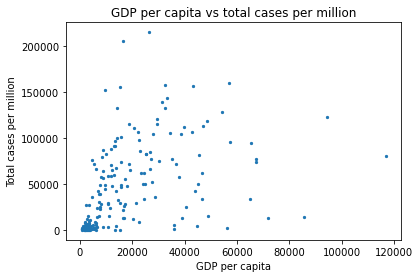

```python
dfCovidGDP = dfCovid[dfCovid['date'] == '2021-09-25'].reset_index()
dfCovidGDP = dfCovidGDP[['location', 'total_cases_per_million', 'total_deaths_per_million', 'gdp_per_capita']]
dfCovidGDP_modified = dfCovidGDP[dfCovidGDP['gdp_per_capita'] < 20000].reset_index()
#print(dfCovidGDP.head(20))

plt.scatter(dfCovidGDP['gdp_per_capita'], dfCovidGDP['total_cases_per_million'], s=5)
plt.title('GDP per capita vs total cases per million')
plt.xlabel('GDP per capita')
plt.ylabel('Total cases per million')
```

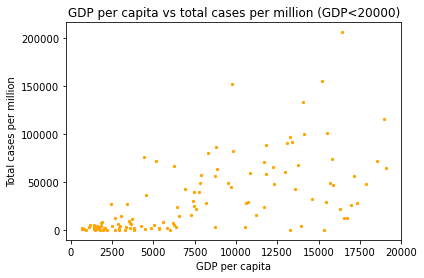

```python
plt.scatter(dfCovidGDP_modified['gdp_per_capita'], dfCovidGDP_modified['total_cases_per_million'], s=5, color='orange')
plt.title('GDP per capita vs total cases per million (GDP<20000)')
plt.xlabel('GDP per capita')
plt.ylabel('Total cases per million')
```

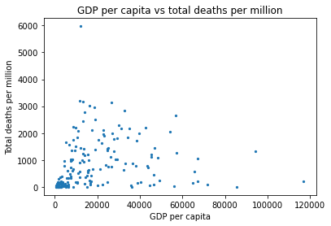

```python
plt.scatter(dfCovidGDP['gdp_per_capita'], dfCovidGDP['total_deaths_per_million'], s=5)
plt.title('GDP per capita vs total deaths per million')
plt.xlabel('GDP per capita')
plt.ylabel('Total deaths per million')
```

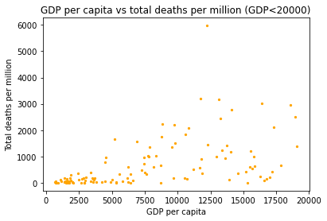

```python
plt.scatter(dfCovidGDP_modified['gdp_per_capita'], dfCovidGDP_modified['total_deaths_per_million'], s=5, color='orange')
plt.title('GDP per capita vs total deaths per million (GDP<20000)')
plt.xlabel('GDP per capita')
plt.ylabel('Total deaths per million')
```

### Male/female smokers versus total deaths

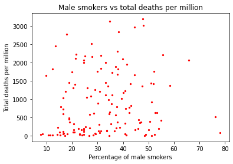

```python
dfCovidSmokers = dfCovid[dfCovid['date'] == '2021-09-25'].reset_index()
dfCovidSmokers = dfCovidSmokers[['location', 'total_deaths_per_million', 'male_smokers', 'female_smokers']]

plt.scatter(dfCovidSmokers['male_smokers'], dfCovidSmokers['total_deaths_per_million'], s=5, color='red', label='Male smokers')
plt.title('Male smokers vs total deaths per million')
plt.xlabel('Percentage of male smokers')
plt.ylabel('Total deaths per million')
```

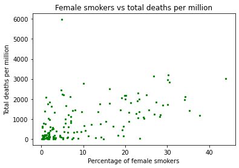

```python
plt.scatter(dfCovidSmokers['female_smokers'], dfCovidSmokers['total_deaths_per_million'], s=5, color='green', label='Female smokers')
plt.title('Female smokers vs total deaths per million')
plt.xlabel('Percentage of female smokers')
plt.ylabel('Total deaths per million')
#plt.ylim([-100, 3500])
#plt.xlim([-2, 30])
```